# IE582 HOMEWORK 1

Nur Deniz Turhan

October 18th 2018

# **Task 1**

## **A.**

To understand if bookmakers are good at deciding over/under 2.5 odds, empirical over and probabilistic over were calculated after both matches and odds data were structured and organized. Probabilities of over were cut into some bins in the range [0,1] with intervals of 0.05. Empirical over is the proportion of number of the games finished over to number of all games in the corresponding bin. Probabilistic over is the average of the probabilities of over. After calculating these two values, five bookmakers’ odds were investigated (both initial and final) if they are successful or not. To this aim, a line going through x=y axis is added to the plot of empirical over versus probabilistic over.Since some bins have few games in summary_table, merging the bins would be meaningful. We can merge the bins having less than (let’s say) five elements with the next or previous bin of the same year.

```
## Classes 'data.table' and 'data.frame':   3122 obs. of  7 variables:
##  $ leagueId: chr  "df9b1196-e3cf-4cc7-9159-f236fe738215" "df9b1196-e3cf-4cc7-9159-f236fe738215" "df9b1196-e3cf-4cc7-9159-f236fe738215" "df9b1196-e3cf-4cc7-9159-f236fe738215" ...
##  $ matchId : chr  "KjF6FiA6" "ILVbJgQm" "SGIEDVvJ" "YwL5xFHJ" ...
##  $ home    : chr  "tottenham" "aston villa" "wolves" "bolton" ...
##  $ away    : chr  "manchester city" "west ham" "stoke city" "fulham" ...
##  $ score   : chr  "0:0" "3:0" "2:1" "0:0" ...
##  $ date    : num  1.28e+09 1.28e+09 1.28e+09 1.28e+09 1.28e+09 ...
##  $ type    : chr  "soccer" "soccer" "soccer" "soccer" ...
##  - attr(*, ".internal.selfref")=<externalptr>
```

```
##     Year odd_cut_over empirical_over probabilistic_over   N
##  1: 2011   (0.4,0.45]      0.3076923          0.4351691  26
##  2: 2011   (0.45,0.5]      0.5156250          0.4789817 128
##  3: 2011   (0.5,0.55]      0.6138614          0.5206914 101
##  4: 2011   (0.55,0.6]      0.4375000          0.5703789  32
##  5: 2011   (0.6,0.65]      0.8181818          0.6215229  11
##  6: 2012   (0.4,0.45]      0.4137931          0.4333402  29
##  7: 2012   (0.45,0.5]      0.5641026          0.4800169 117
##  8: 2012   (0.5,0.55]      0.5546218          0.5237416 119
##  9: 2012   (0.55,0.6]      0.4705882          0.5712134  85
## 10: 2012   (0.6,0.65]      0.6296296          0.6195860  27
## 11: 2013   (0.4,0.45]      0.4545455          0.4325651  33
## 12: 2013   (0.45,0.5]      0.4705882          0.4782124 102
## 13: 2013   (0.5,0.55]      0.5419847          0.5266034 131
## 14: 2013   (0.55,0.6]      0.5538462          0.5723342  65
```

[output cut: 32 more lines]

Now, we can look at the plot of the empirical over vs. probabilistic over for five different bookmakers. We will look for both initial and final odds.Related R codes for the plots below can be found in Appendix.

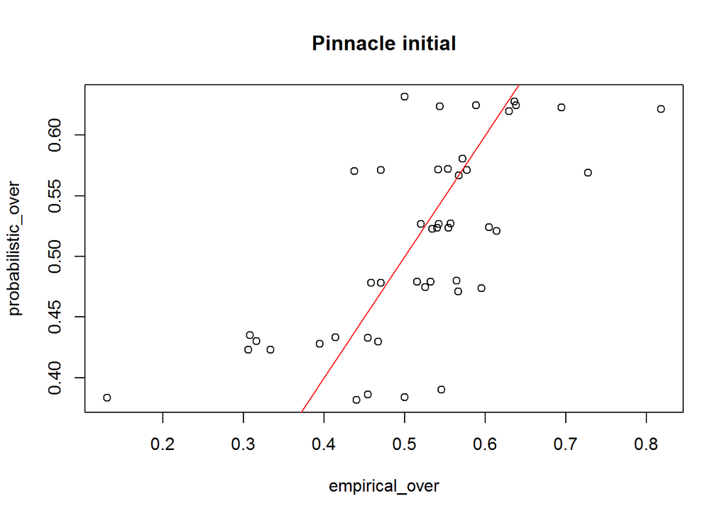

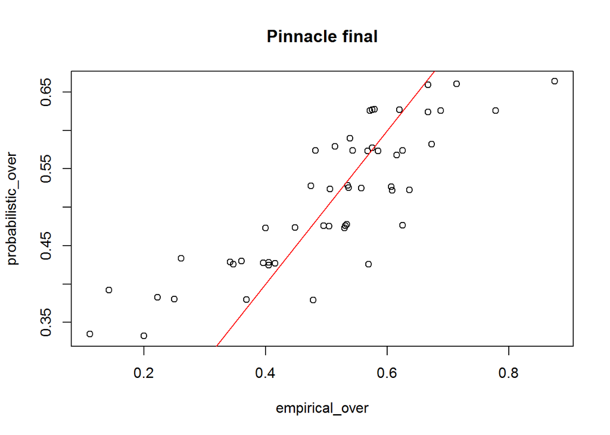

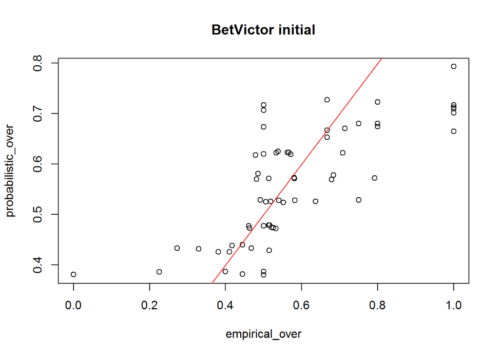

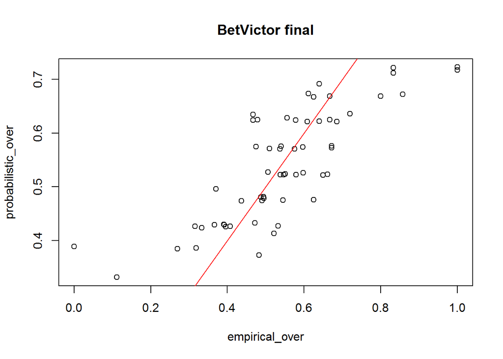

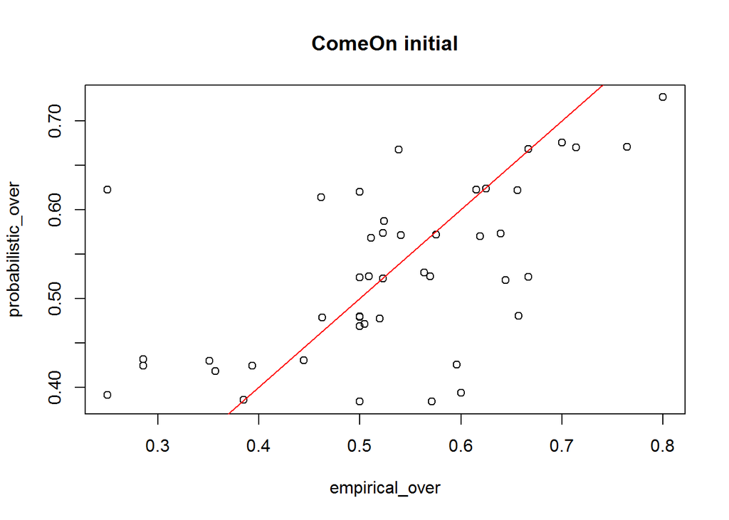

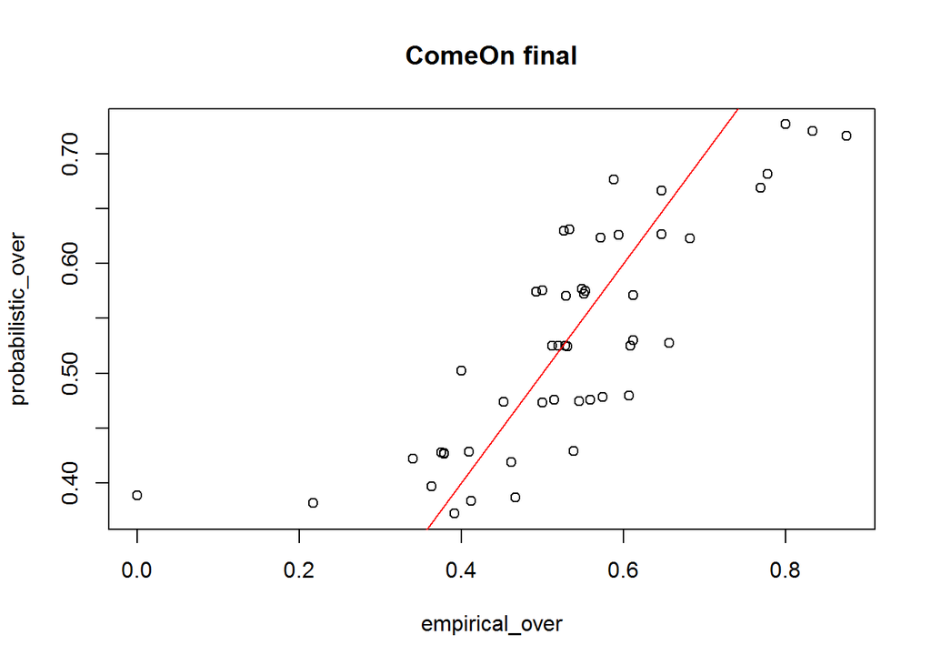

[figure not shown]

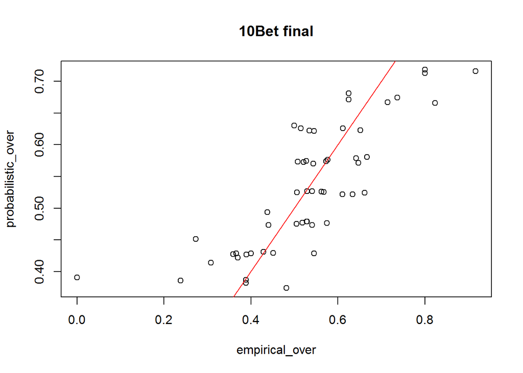

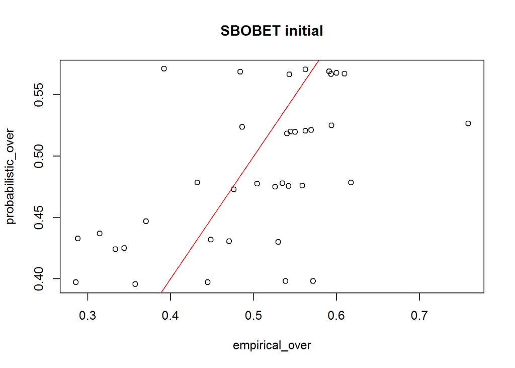

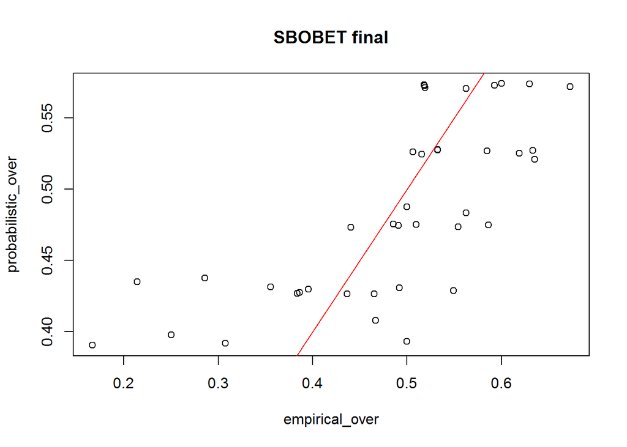

The plots of initial and final odds for five different bookmakers (Pinnacle, BetVictor, ComeOn, 10Bet, SBOBET) can be seen above. Pinnacle can be considered as good at deciding his odds according to the plots since the points are distributed along x=y axis which means the probabilistic overs he predicted and the empirical ones show similarity. Additionally, he is more successful with his final odds. BetVictor is also good at deciding the odds based on the same reasons as Pinnacle. His final odds are more similar with the empirical ones compared to the initial odds. ComeOn is not as good as Pinnacle and BetVictor at predicting his initial odds but he is better at his final odds which are distributed along x=y axis. 10Bet is also good at deciding his both initial and final odds owing to the same reasons as others. SBOBET is not so good at deciding his odds because the plot shows almost random points. There is not a relationship between empirical and probabilistic overs in the initial odds plot whereas there is a slight relation in the final odds. Nevertheless, the points do not show a strong trend as previous bookmakers’.

# **B.**

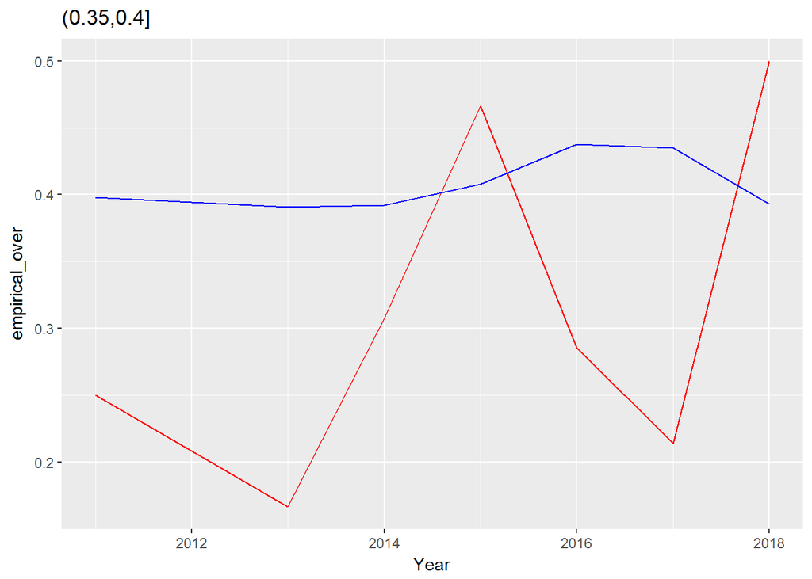

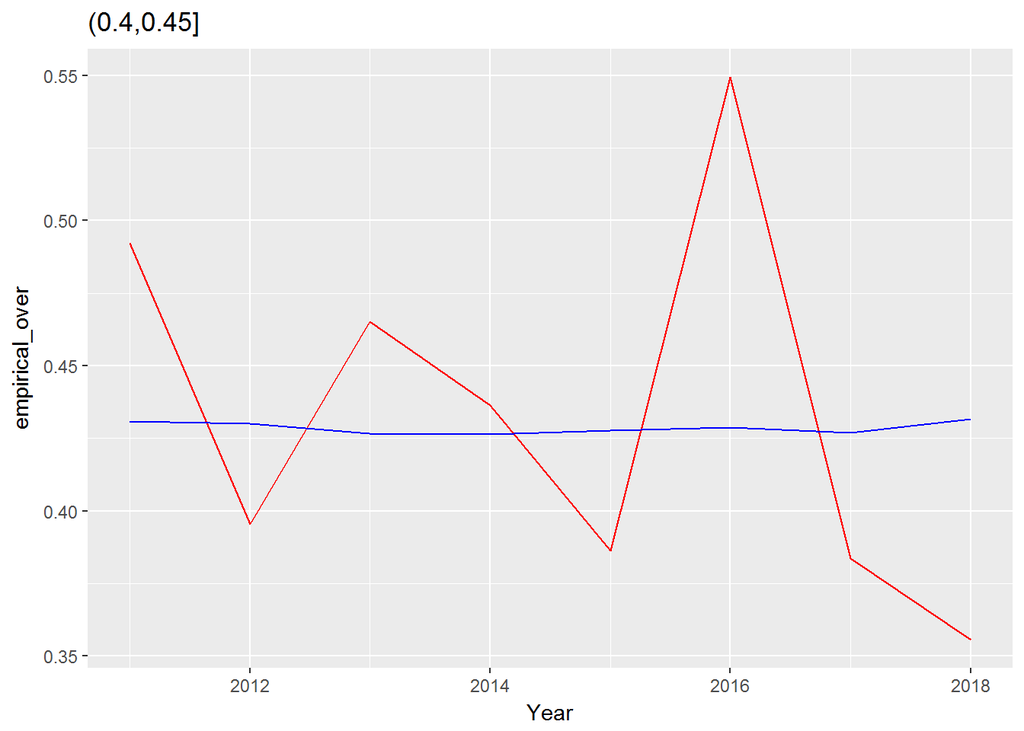

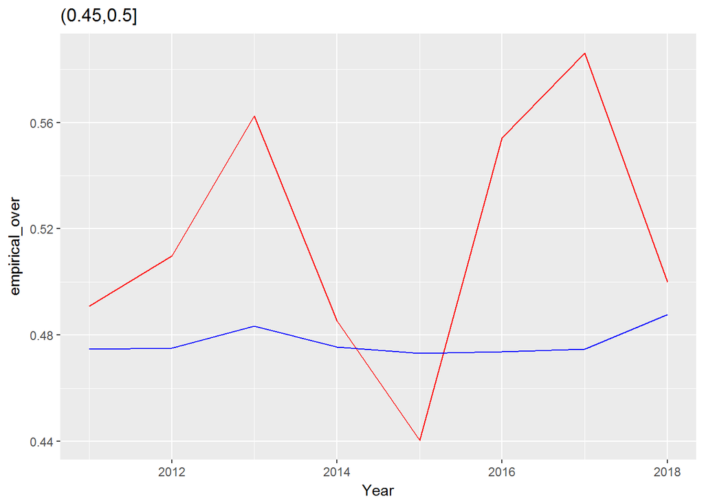

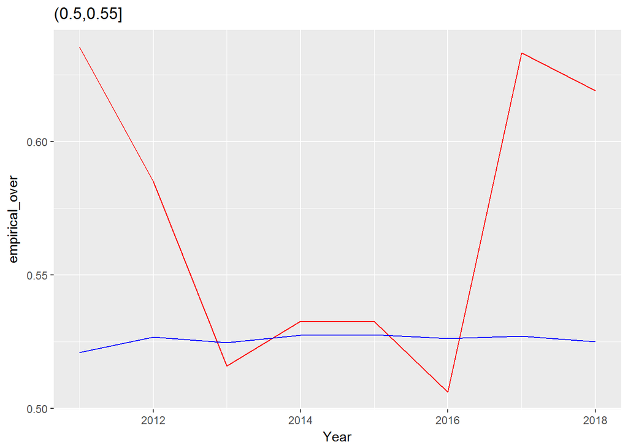

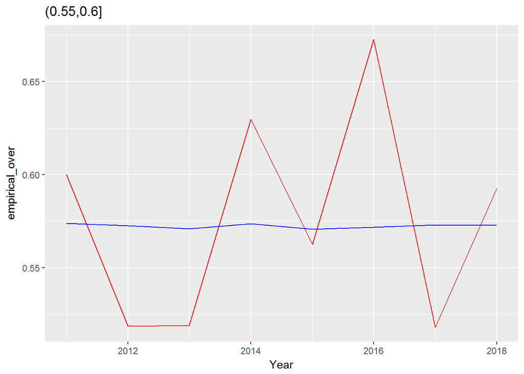

# **Task 2**

For this task, bookmaker ComeOn is chosen and his odds changing over time for different matches are investigated. The changes are examined for each type of odds namely odd1, odd2, and oddX with plots. Since there are huge number of data, only first 200 rows of the data are selected.

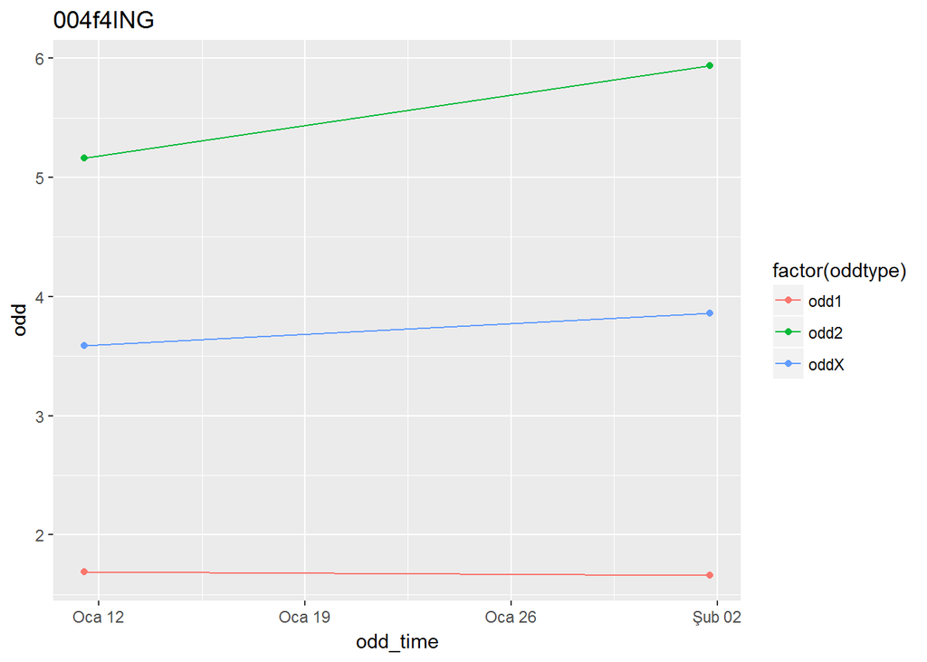

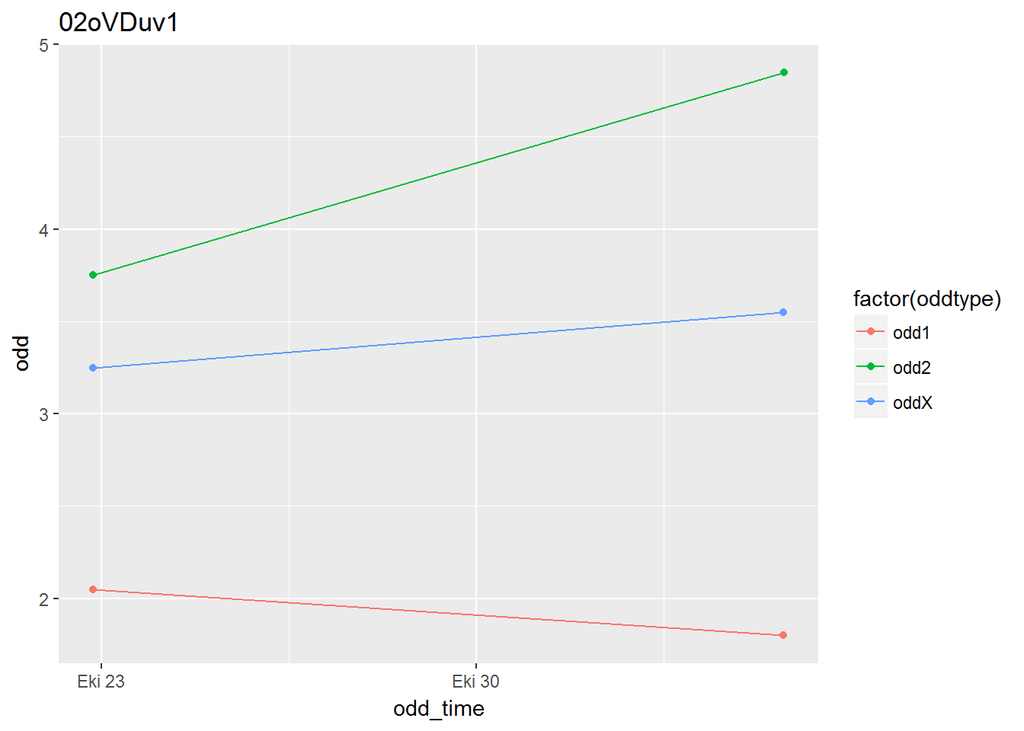

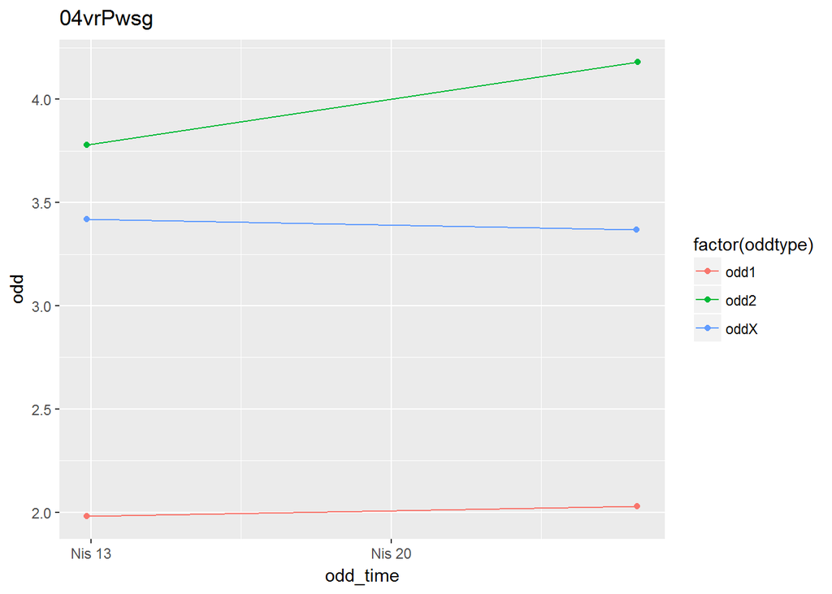

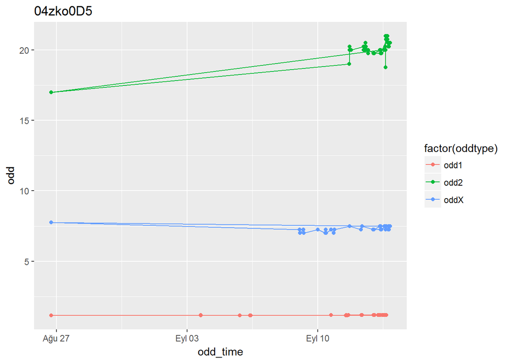

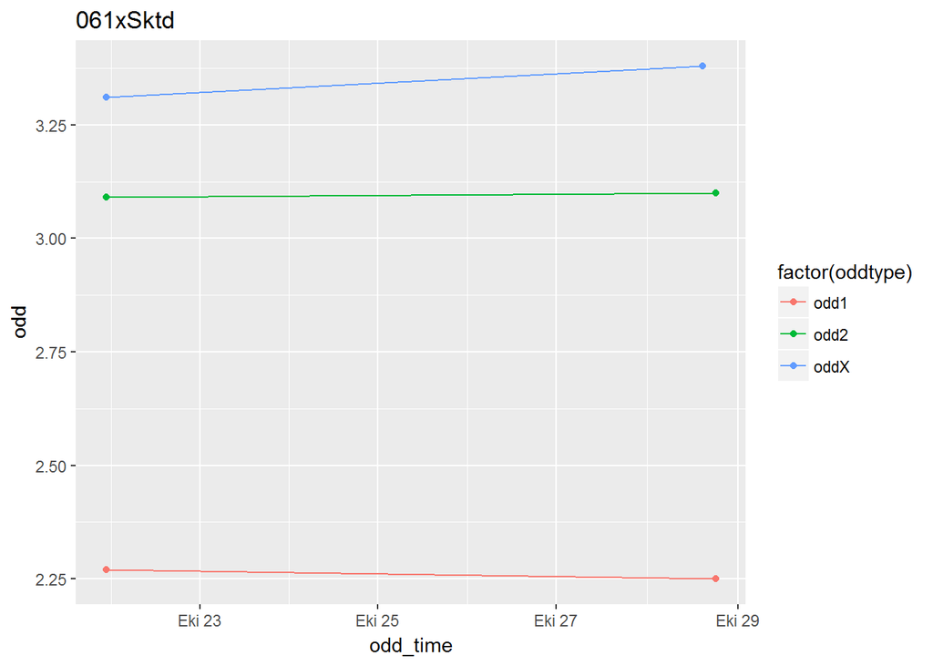

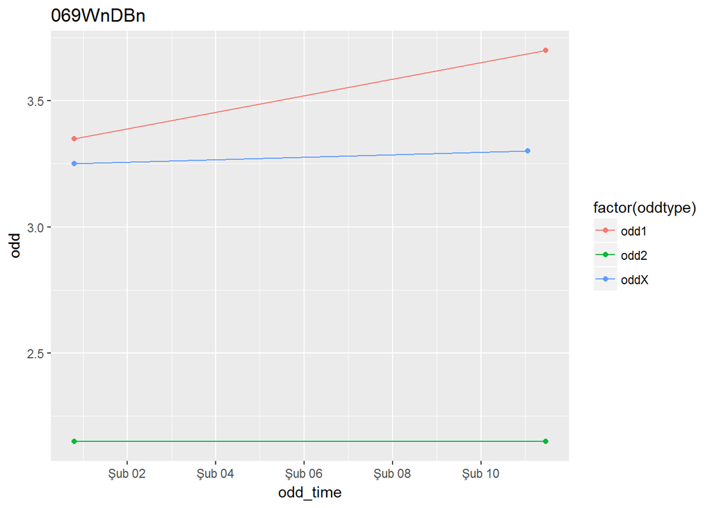

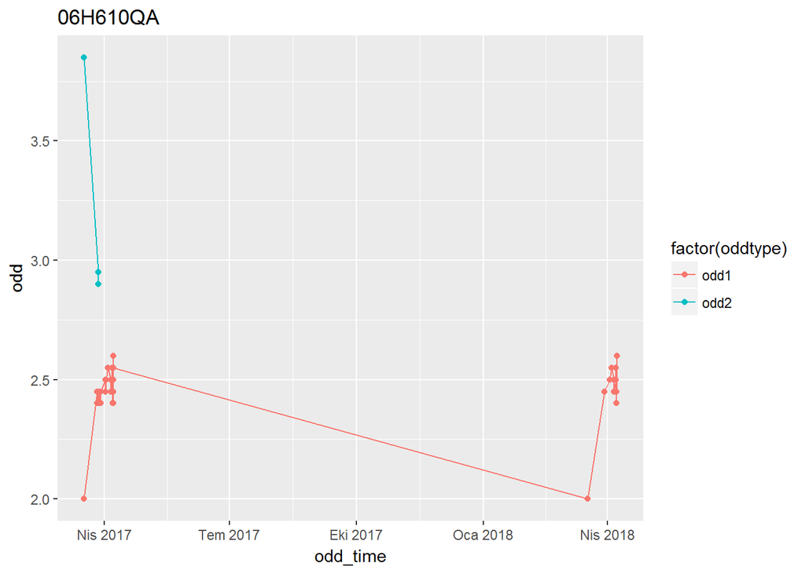

Change of the odds of ComeOn for seven different games over time can be seen on the plots above. The plots can be interpreted in this way: ComeOn changed his odd2 type odds in an ascending way over time whereas he did not change odd1 and oddX types odds so considerably for four of the games. He did not change any type of odds so much for one match and he increased his odd1 type odd and did not change odd2 and oddX types for another match. Another plot shows that he increased his odd1 type odd towards April 2017 and then decreased it in April 2018 to the same with one of April 2017. This can be due to seasonal reasons such as the performance of the teams can show seasonal trends, etc.

# **Appendix**

R codes with necessary explanations

```r
require(data.table)
require(anytime)
require(dplyr)
library(ggplot2)
install.packages("dplyr")
install.packages("anytime")

#task 1 part a#

matches_file_path='C:/Users/casper/Downloads/df9b1196-e3cf-4cc7-9159-f236fe738215_matches.rds'

odd_details_file_path='C:/Users/casper/Downloads/df9b1196-e3cf-4cc7-9159-f236fe738215_odd_details.rds'
matches=readRDS(matches_file_path)
odds=readRDS(odd_details_file_path)
str(matches)
matches=unique(matches)

#transform unix time to date time
matches[,match_time:=anytime(date)]


matches[,c("HomeGoals","AwayGoals"):=tstrsplit(score,':')]

matches[,Year:=year(match_time)]
matches[,Month:=month(match_time)]
matches[,Weekday:=wday(match_time)]
matches[,Hour:=hour(match_time)]

#transform characters to numeric for scores
matches$HomeGoals=as.numeric(matches$HomeGoals)
matches[,AwayGoals:=as.numeric(AwayGoals)]

#calculate total goals
matches[,TotalGoals:=HomeGoals+AwayGoals]

# mark over under
matches[,IsOver:=0]
matches[TotalGoals>2,IsOver:=1]

#yearly average goals
yearly_goals=matches[,list(AvgGoals=mean(TotalGoals)),by=list(Year)]


#filter over under 2.5
odds_over_under=odds[betType=='ou' & totalhandicap=='2.5']


#order data in ascending date
odds_over_under=odds_over_under[order(matchId, oddtype,bookmaker,date)]

odds_over_under_initial=odds_over_under[,list(start_odd=odd[1]),
                              by=list(matchId,oddtype,bookmaker)]

odds_over_under_final=odds_over_under[,list(final_odd=odd[.N]),
                            by=list(matchId,oddtype,bookmaker)]

#get pinnacle initial over under odds
pinnacle_over_under=odds_over_under_initial[bookmaker=='Pinnacle']

pinnacle_wide=dcast(pinnacle_over_under,
                    matchId~oddtype,
                    value.var='start_odd')

# join odds with matches
merged_matches=merge(matches,pinnacle_wide,by='matchId')

merged_matches[,probOver:=1/over]
merged_matches[,probUnder:=1/under]

merged_matches[,totalProb:=probOver+probUnder]

merged_matches[,probOver:=probOver/totalProb]
merged_matches[,probUnder:=probUnder/totalProb]

merged_matches=merged_matches[complete.cases(merged_matches)]
merged_matches[,totalProb:=NULL]

cutpoints=seq(0,1,0.05)
merged_matches[,odd_cut_over:=cut(probOver,cutpoints)]

summary_table=merged_matches[,list(empirical_over=mean(IsOver),
                                   probabilistic_over=mean(probOver),.N),
                             by=list(Year,odd_cut_over)]


summary_table=summary_table[order(Year,odd_cut_over)]

mergebins<-c()
j<-1
for(i in 1:nrow(summary_table)){
  if(summary_table$N[i]<5){
    if(summary_table$Year[i]==summary_table$Year[i-1]){
      summary_table$empirical_over[i-1]<-(summary_table$N[i]*summary_table$empirical_over[i]+summary_table$N[i-1]*summary_table$empirical_over[i-1])/(summary_table$N[i]+summary_table$N[i-1])
      summary_table$probabilistic_over[i-1]<-(summary_table$N[i]*summary_table$probabilistic_over[i]+summary_table$N[i-1]*summary_table$probabilistic_over[i-1])/(summary_table$N[i]+summary_table$N[i-1])
      summary_table$N[i-1]<-summary_table$N[i-1]+summary_table$N[i]
      mergebins[j]<-i
      j<-j+1
    }else{
      summary_table$empirical_over[i+1]<-(summary_table$N[i]*summary_table$empirical_over[i]+summary_table$N[i+1]*summary_table$empirical_over[i+1])/(summary_table$N[i]+summary_table$N[i+1])
      summary_table$probabilistic_over[i+1]<-(summary_table$N[i]*summary_table$probabilistic_over[i]+summary_table$N[i+1]*summary_table$probabilistic_over[i+1])/(summary_table$N[i]+summary_table$N[i+1])
      summary_table$N[i+1]<-summary_table$N[i+1]+summary_table$N[i]
      mergebins[j]<-i
      j<-j+1
    }
  }
}
summary_table<-summary_table[-mergebins,]

plot(summary_table[,list(empirical_over,probabilistic_over)],main="Pinnacle initial",cex=1)
abline(0,1,col='red')

#get pinnacle final over under odds
pinnacle_over_under_f=odds_over_under_final[bookmaker=='Pinnacle']

pinnacle_wide_f=dcast(pinnacle_over_under_f,
                    matchId~oddtype,
                    value.var='final_odd')

# join odds with matches
merged_matches=merge(matches,pinnacle_wide_f,by='matchId')

merged_matches[,probOver:=1/over]
merged_matches[,probUnder:=1/under]

merged_matches[,totalProb:=probOver+probUnder]

merged_matches[,probOver:=probOver/totalProb]

merged_matches[,probUnder:=probUnder/totalProb]

merged_matches=merged_matches[complete.cases(merged_matches)]
merged_matches[,totalProb:=NULL]

cutpoints=seq(0,1,0.05)
merged_matches[,odd_cut_over:=cut(probOver,cutpoints)]

summary_table=merged_matches[,list(empirical_over=mean(IsOver),
                                   probabilistic_over=mean(probOver),.N),
                             by=list(Year,odd_cut_over)]

summary_table=summary_table[order(Year)]

mergebins<-c()
j<-1
for(i in 1:nrow(summary_table)){
  if(summary_table$N[i]<5){
    if(summary_table$Year[i]==summary_table$Year[i-1]){
      summary_table$empirical_over[i-1]<-(summary_table$N[i]*summary_table$empirical_over[i]+summary_table$N[i-1]*summary_table$empirical_over[i-1])/(summary_table$N[i]+summary_table$N[i-1])
      summary_table$probabilistic_over[i-1]<-(summary_table$N[i]*summary_table$probabilistic_over[i]+summary_table$N[i-1]*summary_table$probabilistic_over[i-1])/(summary_table$N[i]+summary_table$N[i-1])
      summary_table$N[i-1]<-summary_table$N[i-1]+summary_table$N[i]
      mergebins[j]<-i
      j<-j+1
    }else{
      summary_table$empirical_over[i+1]<-(summary_table$N[i]*summary_table$empirical_over[i]+summary_table$N[i+1]*summary_table$empirical_over[i+1])/(summary_table$N[i]+summary_table$N[i+1])
      summary_table$probabilistic_over[i+1]<-(summary_table$N[i]*summary_table$probabilistic_over[i]+summary_table$N[i+1]*summary_table$probabilistic_over[i+1])/(summary_table$N[i]+summary_table$N[i+1])
      summary_table$N[i+1]<-summary_table$N[i+1]+summary_table$N[i]
      mergebins[j]<-i
      j<-j+1
    }
  }
}
summary_table<-summary_table[-mergebins,]

plot(summary_table[,list(empirical_over,probabilistic_over)],main="Pinnacle final",cex=1)
abline(0,1,col='red')
```

```r
#get BetVictor initial over under odds
betvictor_over_under=odds_over_under_initial[bookmaker=='BetVictor']

betvictor_wide=dcast(betvictor_over_under,
                    matchId~oddtype,
                    value.var='start_odd')

# join odds with matches
merged_matches=merge(matches,betvictor_wide,by='matchId')

merged_matches[,probOver:=1/over]
merged_matches[,probUnder:=1/under]

merged_matches[,totalProb:=probOver+probUnder]

merged_matches[,probOver:=probOver/totalProb]
merged_matches[,probUnder:=probUnder/totalProb]

merged_matches=merged_matches[complete.cases(merged_matches)]
merged_matches[,totalProb:=NULL]

cutpoints=seq(0,1,0.05)
merged_matches[,odd_cut_over:=cut(probOver,cutpoints)]

summary_table=merged_matches[,list(empirical_over=mean(IsOver),
                                   probabilistic_over=mean(probOver),.N),
                             by=list(Year,odd_cut_over)]

summary_table=summary_table[order(Year)]

plot(summary_table[,list(empirical_over,probabilistic_over)],main="BetVictor initial",cex=1)
abline(0,1,col='red')

#get BetVictor final over under odds
betvictor_over_under_f=odds_over_under_final[bookmaker=='BetVictor']

betvictor_wide_f=dcast(betvictor_over_under_f,
                   matchId~oddtype,
                   value.var='final_odd')

# join odds with matches
merged_matches=merge(matches,betvictor_wide_f,by='matchId')

merged_matches[,probOver:=1/over]
merged_matches[,probUnder:=1/under]

merged_matches[,totalProb:=probOver+probUnder]

merged_matches[,probOver:=probOver/totalProb]
merged_matches[,probUnder:=probUnder/totalProb]

merged_matches=merged_matches[complete.cases(merged_matches)]
merged_matches[,totalProb:=NULL]

cutpoints=seq(0,1,0.05)
merged_matches[,odd_cut_over:=cut(probOver,cutpoints)]

summary_table=merged_matches[,list(empirical_over=mean(IsOver),
                                   probabilistic_over=mean(probOver),.N),
                             by=list(Year,odd_cut_over)]

summary_table=summary_table[order(Year)]

mergebins<-c()
j<-1
for(i in 1:nrow(summary_table)){
  if(summary_table$N[i]<5){
    if(summary_table$Year[i]==summary_table$Year[i-1]){
      summary_table$empirical_over[i-1]<-(summary_table$N[i]*summary_table$empirical_over[i]+summary_table$N[i-1]*summary_table$empirical_over[i-1])/(summary_table$N[i]+summary_table$N[i-1])
      summary_table$probabilistic_over[i-1]<-(summary_table$N[i]*summary_table$probabilistic_over[i]+summary_table$N[i-1]*summary_table$probabilistic_over[i-1])/(summary_table$N[i]+summary_table$N[i-1])
      summary_table$N[i-1]<-summary_table$N[i-1]+summary_table$N[i]
      mergebins[j]<-i
      j<-j+1
    }else{
      summary_table$empirical_over[i+1]<-(summary_table$N[i]*summary_table$empirical_over[i]+summary_table$N[i+1]*summary_table$empirical_over[i+1])/(summary_table$N[i]+summary_table$N[i+1])
      summary_table$probabilistic_over[i+1]<-(summary_table$N[i]*summary_table$probabilistic_over[i]+summary_table$N[i+1]*summary_table$probabilistic_over[i+1])/(summary_table$N[i]+summary_table$N[i+1])
      summary_table$N[i+1]<-summary_table$N[i+1]+summary_table$N[i]
      mergebins[j]<-i
      j<-j+1
    }
  }
}
summary_table<-summary_table[-mergebins,]

plot(summary_table[,list(empirical_over,probabilistic_over)],main="BetVictor final",cex=1)
abline(0,1,col='red')

#get ComeOn initial over under odds
comeon_over_under=odds_over_under_initial[bookmaker=='ComeOn']

comeon_wide=dcast(comeon_over_under,
                    matchId~oddtype,
                    value.var='start_odd')

# join odds with matches
merged_matches=merge(matches,comeon_wide,by='matchId')

merged_matches[,probOver:=1/over]
merged_matches[,probUnder:=1/under]

merged_matches[,totalProb:=probOver+probUnder]

merged_matches[,probOver:=probOver/totalProb]
merged_matches[,probUnder:=probUnder/totalProb]

merged_matches=merged_matches[complete.cases(merged_matches)]
merged_matches[,totalProb:=NULL]

cutpoints=seq(0,1,0.05)
merged_matches[,odd_cut_over:=cut(probOver,cutpoints)]

summary_table=merged_matches[,list(empirical_over=mean(IsOver),
                                   probabilistic_over=mean(probOver),.N),
                             by=list(Year,odd_cut_over)]

summary_table=summary_table[order(Year)]

mergebins<-c()
j<-1
for(i in 1:nrow(summary_table)){
  if(summary_table$N[i]<5){
    if(summary_table$Year[i]==summary_table$Year[i-1]){
      summary_table$empirical_over[i-1]<-(summary_table$N[i]*summary_table$empirical_over[i]+summary_table$N[i-1]*summary_table$empirical_over[i-1])/(summary_table$N[i]+summary_table$N[i-1])
      summary_table$probabilistic_over[i-1]<-(summary_table$N[i]*summary_table$probabilistic_over[i]+summary_table$N[i-1]*summary_table$probabilistic_over[i-1])/(summary_table$N[i]+summary_table$N[i-1])
      summary_table$N[i-1]<-summary_table$N[i-1]+summary_table$N[i]
      mergebins[j]<-i
      j<-j+1
    }else{
      summary_table$empirical_over[i+1]<-(summary_table$N[i]*summary_table$empirical_over[i]+summary_table$N[i+1]*summary_table$empirical_over[i+1])/(summary_table$N[i]+summary_table$N[i+1])
      summary_table$probabilistic_over[i+1]<-(summary_table$N[i]*summary_table$probabilistic_over[i]+summary_table$N[i+1]*summary_table$probabilistic_over[i+1])/(summary_table$N[i]+summary_table$N[i+1])
      summary_table$N[i+1]<-summary_table$N[i+1]+summary_table$N[i]
      mergebins[j]<-i
      j<-j+1
    }
  }
}
summary_table<-summary_table[-mergebins,]

plot(summary_table[,list(empirical_over,probabilistic_over)],main="ComeOn initial",cex=1)
abline(0,1,col='red')

#get ComeOn final over under odds
comeon_over_under_f=odds_over_under_final[bookmaker=='ComeOn']

comeon_wide_f=dcast(comeon_over_under_f,
                  matchId~oddtype,
                  value.var='final_odd')

# join odds with matches
merged_matches=merge(matches,comeon_wide_f,by='matchId')

merged_matches[,probOver:=1/over]
merged_matches[,probUnder:=1/under]

merged_matches[,totalProb:=probOver+probUnder]

merged_matches[,probOver:=probOver/totalProb]
merged_matches[,probUnder:=probUnder/totalProb]
```

```r
merged_matches=merged_matches[complete.cases(merged_matches)]
merged_matches[,totalProb:=NULL]

cutpoints=seq(0,1,0.05)
merged_matches[,odd_cut_over:=cut(probOver,cutpoints)]

summary_table=merged_matches[,list(empirical_over=mean(IsOver),
                                   probabilistic_over=mean(probOver),.N),
                             by=list(Year,odd_cut_over)]

summary_table=summary_table[order(Year)]

mergebins<-c()
j<-1
for(i in 1:nrow(summary_table)){
  if(summary_table$N[i]<5){
    if(summary_table$Year[i]==summary_table$Year[i-1]){
      summary_table$empirical_over[i-1]<-(summary_table$N[i]*summary_table$empirical_over[i]+summary_table$N[i-1]*summary_table$empirical_over[i-1])/(summary_table$N[i]+summary_table$N[i-1])
      summary_table$probabilistic_over[i-1]<-(summary_table$N[i]*summary_table$probabilistic_over[i]+summary_table$N[i-1]*summary_table$probabilistic_over[i-1])/(summary_table$N[i]+summary_table$N[i-1])
      summary_table$N[i-1]<-summary_table$N[i-1]+summary_table$N[i]
      mergebins[j]<-i
      j<-j+1
    }else{
      summary_table$empirical_over[i+1]<-(summary_table$N[i]*summary_table$empirical_over[i]+summary_table$N[i+1]*summary_table$empirical_over[i+1])/(summary_table$N[i]+summary_table$N[i+1])
      summary_table$probabilistic_over[i+1]<-(summary_table$N[i]*summary_table$probabilistic_over[i]+summary_table$N[i+1]*summary_table$probabilistic_over[i+1])/(summary_table$N[i]+summary_table$N[i+1])
      summary_table$N[i+1]<-summary_table$N[i+1]+summary_table$N[i]
      mergebins[j]<-i
      j<-j+1
    }
  }
}
summary_table<-summary_table[-mergebins,]

plot(summary_table[,list(empirical_over,probabilistic_over)],main="ComeOn final",cex=1)
abline(0,1,col='red')

#get 10Bet initial over under odds
tenbet_over_under=odds_over_under_initial[bookmaker=='10Bet']

tenbet_wide=dcast(tenbet_over_under,
                   matchId~oddtype,
                   value.var='start_odd')

# join odds with matches
merged_matches=merge(matches,tenbet_wide,by='matchId')

merged_matches[,probOver:=1/over]
merged_matches[,probUnder:=1/under]

merged_matches[,totalProb:=probOver+probUnder]

merged_matches[,probOver:=probOver/totalProb]
merged_matches[,probUnder:=probUnder/totalProb]

merged_matches=merged_matches[complete.cases(merged_matches)]
merged_matches[,totalProb:=NULL]

cutpoints=seq(0,1,0.05)
merged_matches[,odd_cut_over:=cut(probOver,cutpoints)]

summary_table=merged_matches[,list(empirical_over=mean(IsOver),
                                   probabilistic_over=mean(probOver),.N),
                             by=list(Year,odd_cut_over)]

summary_table=summary_table[order(Year)]

plot(summary_table[,list(empirical_over,probabilistic_over)],main="10Bet initial",cex=4)
abline(0,1,col='red')

#get 10Bet final over under odds
tenbet_over_under_f=odds_over_under_final[bookmaker=='10Bet']

tenbet_wide_f=dcast(tenbet_over_under_f,
                  matchId~oddtype,
                  value.var='final_odd')

# join odds with matches
merged_matches=merge(matches,tenbet_wide_f,by='matchId')

merged_matches[,probOver:=1/over]
merged_matches[,probUnder:=1/under]

merged_matches[,totalProb:=probOver+probUnder]

merged_matches[,probOver:=probOver/totalProb]
merged_matches[,probUnder:=probUnder/totalProb]

merged_matches=merged_matches[complete.cases(merged_matches)]
merged_matches[,totalProb:=NULL]

cutpoints=seq(0,1,0.05)
merged_matches[,odd_cut_over:=cut(probOver,cutpoints)]

summary_table=merged_matches[,list(empirical_over=mean(IsOver),
                                   probabilistic_over=mean(probOver),.N),
                             by=list(Year,odd_cut_over)]

summary_table=summary_table[order(Year)]

mergebins<-c()
j<-1
for(i in 1:nrow(summary_table)){
  if(summary_table$N[i]<5){
    if(summary_table$Year[i]==summary_table$Year[i-1]){
      summary_table$empirical_over[i-1]<-(summary_table$N[i]*summary_table$empirical_over[i]+summary_table$N[i-1]*summary_table$empirical_over[i-1])/(summary_table$N[i]+summary_table$N[i-1])
      summary_table$probabilistic_over[i-1]<-(summary_table$N[i]*summary_table$probabilistic_over[i]+summary_table$N[i-1]*summary_table$probabilistic_over[i-1])/(summary_table$N[i]+summary_table$N[i-1])
      summary_table$N[i-1]<-summary_table$N[i-1]+summary_table$N[i]
      mergebins[j]<-i
      j<-j+1
    }else{
      summary_table$empirical_over[i+1]<-(summary_table$N[i]*summary_table$empirical_over[i]+summary_table$N[i+1]*summary_table$empirical_over[i+1])/(summary_table$N[i]+summary_table$N[i+1])
      summary_table$probabilistic_over[i+1]<-(summary_table$N[i]*summary_table$probabilistic_over[i]+summary_table$N[i+1]*summary_table$probabilistic_over[i+1])/(summary_table$N[i]+summary_table$N[i+1])
      summary_table$N[i+1]<-summary_table$N[i+1]+summary_table$N[i]
      mergebins[j]<-i
      j<-j+1
    }
  }
}
summary_table<-summary_table[-mergebins,]
plot(summary_table[,list(empirical_over,probabilistic_over)],main="10Bet final",cex=1)
abline(0,1,col='red')

#get SBOBET initial over under odds
sbobet_over_under=odds_over_under_initial[bookmaker=='SBOBET']

sbobet_wide=dcast(sbobet_over_under,
                  matchId~oddtype,
                  value.var='start_odd')

# join odds with matches
merged_matches=merge(matches,sbobet_wide,by='matchId')

merged_matches[,probOver:=1/over]
merged_matches[,probUnder:=1/under]

merged_matches[,totalProb:=probOver+probUnder]

merged_matches[,probOver:=probOver/totalProb]
merged_matches[,probUnder:=probUnder/totalProb]

merged_matches=merged_matches[complete.cases(merged_matches)]
merged_matches[,totalProb:=NULL]

cutpoints=seq(0,1,0.05)
merged_matches[,odd_cut_over:=cut(probOver,cutpoints)]

summary_table=merged_matches[,list(empirical_over=mean(IsOver),
                                   probabilistic_over=mean(probOver),.N),
                             by=list(Year,odd_cut_over)]

summary_table=summary_table[order(Year)]

mergebins<-c()
j<-1
for(i in 1:nrow(summary_table)){
  if(summary_table$N[i]<5){
    if(summary_table$Year[i]==summary_table$Year[i-1]){
      summary_table$empirical_over[i-1]<-(summary_table$N[i]*summary_table$empirical_over[i]+summary_table$N[i-1]*summary_table$empirical_over[i-1])/(summary_table$N[i]+summary_table$N[i-1])
      summary_table$probabilistic_over[i-1]<-(summary_table$N[i]*summary_table$probabilistic_over[i]+summary_table$N[i-1]*summary_table$probabilistic_over[i-1])/(summary_table$N[i]+summary_table$N[i-1])
      summary_table$N[i-1]<-summary_table$N[i-1]+summary_table$N[i]
      mergebins[j]<-i
      j<-j+1
    }else{
      summary_table$empirical_over[i+1]<-(summary_table$N[i]*summary_table$empirical_over[i]+summary_table$N[i+1]*summary_table$empirical_over[i+1])/(summary_table$N[i]+summary_table$N[i+1])
      summary_table$probabilistic_over[i+1]<-(summary_table$N[i]*summary_table$probabilistic_over[i]+summary_table$N[i+1]*summary_table$probabilistic_over[i+1])/(summary_table$N[i]+summary_table$N[i+1])
      summary_table$N[i+1]<-summary_table$N[i+1]+summary_table$N[i]
      mergebins[j]<-i
      j<-j+1
    }
  }
}
summary_table<-summary_table[-mergebins,]
```

```r
plot(summary_table[,list(empirical_over,probabilistic_over)],main="SBOBET initial",cex=1)
abline(0,1,col='red')

#get SBOBET final over under odds
sbobet_over_under_f=odds_over_under_final[bookmaker=='SBOBET']

sbobet_wide_f=dcast(sbobet_over_under_f,
                matchId~oddtype,
                value.var='final_odd')

# join odds with matches
merged_matches=merge(matches,sbobet_wide_f,by='matchId')

merged_matches[,probOver:=1/over]
merged_matches[,probUnder:=1/under]

merged_matches[,totalProb:=probOver+probUnder]

merged_matches[,probOver:=probOver/totalProb]
merged_matches[,probUnder:=probUnder/totalProb]

merged_matches=merged_matches[complete.cases(merged_matches)]
merged_matches[,totalProb:=NULL]

cutpoints=seq(0,1,0.05)
merged_matches[,odd_cut_over:=cut(probOver,cutpoints)]

summary_table=merged_matches[,list(empirical_over=mean(IsOver),
                                   probabilistic_over=mean(probOver),.N),
                             by=list(Year,odd_cut_over)]


summary_table=summary_table[order(Year)]

mergebins<-c()
j<-1
for(i in 1:nrow(summary_table)){
  if(summary_table$N[i]<5){
    if(summary_table$Year[i]==summary_table$Year[i-1]){
      summary_table$empirical_over[i-1]<-(summary_table$N[i]*summary_table$empirical_over[i]+summary_table$N[i-1]*summary_table$empirical_over[i-1])/(summary_table$N[i]+summary_table$N[i-1])
      summary_table$probabilistic_over[i-1]<-(summary_table$N[i]*summary_table$probabilistic_over[i]+summary_table$N[i-1]*summary_table$probabilistic_over[i-1])/(summary_table$N[i]+summary_table$N[i-1])
      summary_table$N[i-1]<-summary_table$N[i-1]+summary_table$N[i]
      mergebins[j]<-i
      j<-j+1
    }else{
      summary_table$empirical_over[i+1]<-(summary_table$N[i]*summary_table$empirical_over[i]+summary_table$N[i+1]*summary_table$empirical_over[i+1])/(summary_table$N[i]+summary_table$N[i+1])
      summary_table$probabilistic_over[i+1]<-(summary_table$N[i]*summary_table$probabilistic_over[i]+summary_table$N[i+1]*summary_table$probabilistic_over[i+1])/(summary_table$N[i]+summary_table$N[i+1])
      summary_table$N[i+1]<-summary_table$N[i+1]+summary_table$N[i]
      mergebins[j]<-i
      j<-j+1
    }
  }
}
summary_table<-summary_table[-mergebins,]

plot(summary_table[,list(empirical_over,probabilistic_over)],main="SBOBET final",cex=1)
abline(0,1,col='red')



#Task1 part b#

drawtheplot<-summary_table%>% group_by(odd_cut_over) %>% do(plots=ggplot(data=.) +
                                    aes(x=Year)+geom_line(aes(y=empirical_over),colour="red")+geom_line(aes(y=probabilistic_over),colour="blue") + ggtitle(unique(.$odd_cut_over)))
drawtheplot$plots


#task2#
odds[,odd_time:=anytime(date)]
changeoftheodds<-odds[betType=="1x2"& bookmaker=="ComeOn"]
choosesomeofthem<-changeoftheodds[1:200,]

plotofodds<-choosesomeofthem%>%group_by(matchId)%>%do(plots=ggplot(., aes(odd_time, odd, color = factor(oddtype)))+
  geom_path() +
  geom_point()+ ggtitle(unique(.$matchId)))

plotofodds$plots
```